# Stoops Effect

Matthew Bladek

### What is the Stroop Effect?

“In psychology, the Stroop effect is a demonstration of interference in the reaction time of a task.

When the name of a color (e.g., “blue”, “green”, or “red”) is printed in a color which is not denoted by the name (i.e., the word “red” printed in blue ink instead of red ink), naming the color of the word takes longer and is more prone to errors than when the color of the ink matches the name of the color." https://en.wikipedia.org/wiki/Stroop_effect

### Stroop Task

“In a Stroop task, participants are presented with a list of words, with each word displayed in a color of ink. The participant’s task is to say out loud the color of the ink in which the word is printed. The task has two conditions: a congruent words condition, and an incongruent words condition. In the congruent words condition, the words being displayed are color words whose names match the colors in which they are printed: for example RED, BLUE. In the incongruent words condition, the words displayed are color words whose names do not match the colors in which they are printed: for example PURPLE, ORANGE. In each case, we measure the time it takes to name the ink colors in equally-sized lists. Each participant will go through and record a time from each condition.”

https://docs.google.com/document/d/1-OkpZLjG_kX9J6LIQ5IltsqMzVWjh36QpnP2RYpVdPU/pub?embedded=True

### Experiment Design

The experiment was a website where it measured the time it took to name several words in both a base case and a treatment case. The treatment being whether the words and the colors were congruent or not.

https://faculty.washington.edu/chudler/java/ready.html

In this experiment the dependent variable is the reaction time to name all of the words on the screen. We will refer to this as the “reaction time” from here on out. Our independent variable or treatment is whether the words are congruent with their color or not.

The null hypothesis is that there is no difference between reaction time or that having incongruent colors actually decreases the reaction time.

The alternative hypothesis is that there is an increase in reaction time.  
We suspect that having incongruent colors would cause mental dissonance and thus positively affect reaction time. Thus we will perform a 1 sided t-test in the positive direction.

The data provided was from Udacity, there were 24 observations giving the reaction time before and after the treatment. The time is in seconds. I took the test myself with a Congruent time of: 10.866 seconds and a Incongruent time of: 11.059. We will addd this to our exisiting data to have a total of 25 observations

### The Reaction Time Histrogram

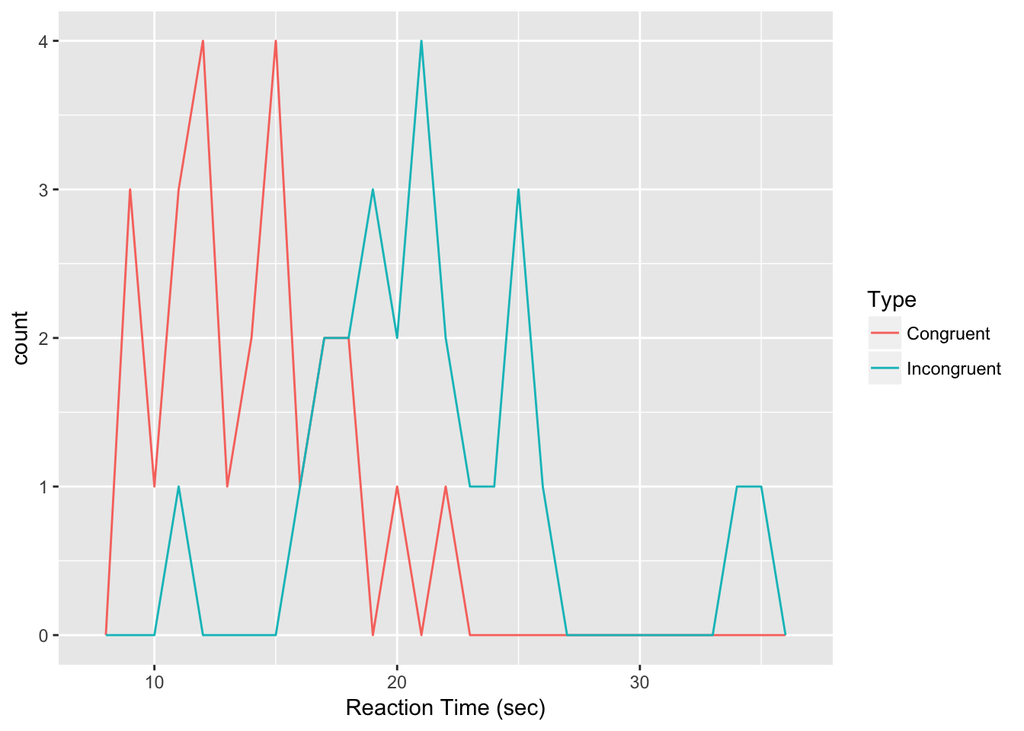

As we can see the distriubtion of the Congruent words and colors was centered less than the Incongruent letters. Both were roughly normally distributed.

There were two outliers above 30 sec for incongruent words.

### The Reaction Time BoxPlot

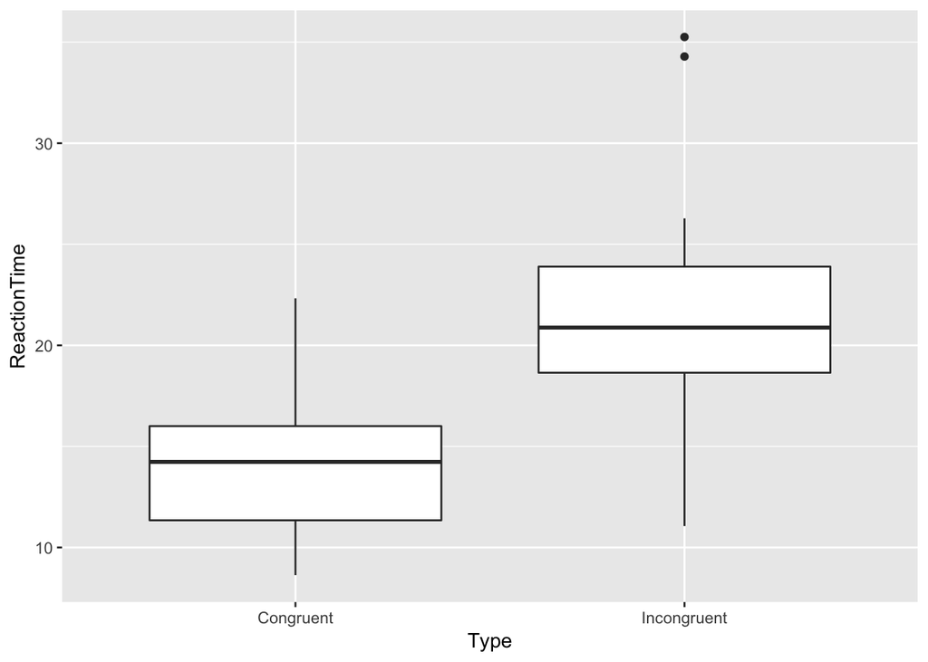

A box plot the two types shows a clear shift in the reaction time between the two. We also see two outliers in the data >30 seconds which lie around 2 standard deviations above the mean.

We will remove these two cases from our study as they are significant outliers.

### Experimental Results

| Statistic | Congruent (sec) | Incongruent (sec) | Differences (sec) |
| --- | --- | --- | --- |
| Mean | 13.81 | 20.43 | 6.624 |
| SD |  |  | 3.6077 |

| Statistic | Value |
| --- | --- |
| Sample Size (N) | 23 |
| Degrees of Freedom (DF) | 22 |
| Alpha Level | .05 |
| One or Two sided | One sided, positive |
| tcritical | 1.7138 |
| Average Mean Difference | 6.624 sec |
| Standard Eror of the Mean | 0.752 sec |
| Cohen’s D | 1.835 |
| R^2 | 77.8% |
| Margin of Error | 1.292 sec |
| Confidence Interval 95% Upper | 7.912 sec |
| Confidence Interval 95% Lower | 5.328 sec |
| t | 8.800 |
| p-value | 5.852e-09 |

### Results:

CI = (5.328, 7.912)

t(22) = 8.800, p = 5.852e-09 < 0.05, one-tailed

The results are clear that there is an extremely low probability that reaction time is decreased or not changed by the treatment. Therefore, we reject the null hypothesis in favor of the alternative hypothesis that the color congruency of the words does affect reaction time.

### Extensions

Exentsions of this project is to see what exactly is at the root of the difference. One might hypothesize that it’s the brains connection between color and writing that has to be reprogrammed which casuses this lag. Another study might involve people who speak a foriegn language and give them this test. There is no built up association between the color and the word in the brain therefore one would not expect to see that there would be a lag. A longitudinal extension of this would be to take this same group over a period of time, giving them the same test and observing the differences once they start making the accociations between the words and colors.